# How Does Racial-Makeup of a School District Affect it’s Different Metrics?

2022-11-29

## Required Packages

```r
library(dplyr)
library(ggplot2)
```

## Massachusett’s Public Schools

[figure not shown]

image from Brokton Public Schools

## Racial Makeup

Histogram of the racial makeup of Mass school districts

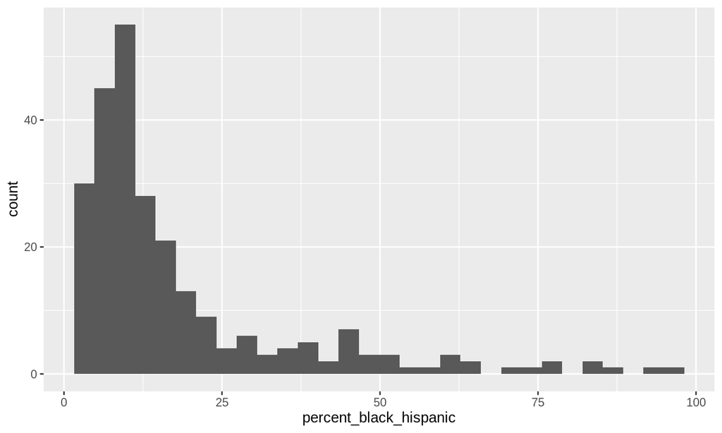

## Two questions

1. Does the ethnicity make up of a school district effect art courses offered, sat performance, disciplinary action, and teacher salaries?
2. What limits the data from clearly answering the above questions?

## Data Sets Used

All proportion data is made using the number of total students in the district.

proportion data set

| District.Name | Average.Salary | Total.Students | percent_students_in_art | White.. | percent_black_hispanic | percent_take_sat | percent_disciplined | percent_poc |
| --- | --- | --- | --- | --- | --- | --- | --- | --- |
| Abington | 94149 | 2107 | 79.44945 | 78.7 | 16.5 | 5.980066 | 3.654485 | >5% & <30% |
| Acton-Boxborough | 89246 | 5164 | 76.41363 | 51.6 | 9.7 | 8.694810 | 1.258714 | >5% & <30% |
| Agawam | 84533 | 3357 | 86.02919 | 80.3 | 13.1 | 3.157581 | 3.991659 | >5% & <30% |
| Amesbury | 81751 | 1830 | 90.71038 | 82.6 | 11.6 | 5.519126 | 2.185792 | >5% & <30% |
| Amherst-Pelham | 85588 | 1285 | 71.12840 | 54.6 | 26.8 | 9.883268 | 1.556420 | >5% & <30% |

## Grouped_by Data

grouped_by averages

| percent_poc | percent_students_in_art | percent_take_sat | percent_disciplined | average_salary |
| --- | --- | --- | --- | --- |
| <5% | 71.86680 | 8.091280 | 2.612414 | 82792.00 |
| >30% & <50% | 65.21132 | 4.442870 | 6.618550 | 84310.79 |
| >5% & <30% | 75.15793 | 6.626264 | 3.915059 | 81911.31 |
| >50% | 72.13418 | 3.432462 | 6.812233 | 83127.79 |

## Data Limitations

1. The different percent poc groups assigned to the school districts are of drastically different sizes. Due to the predominant whiteness of Massachuesetts, there are few school districts with over 50% poc students.
2. Percent of students taking the sat seems small for all school districts because I divided the number of students who took the SAT by the total students in the district.
3. Data represents only public schools.

## Average Salary

little difference is seen amongst different percent groups. Could represent good allocation of state funds.

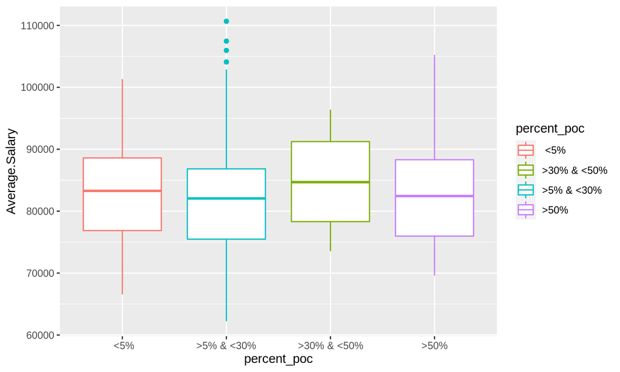

## Students in Art Classes

Data does show a slight decrease in percent of students in art classes in higher percentile poc groups, though there is significant variance.

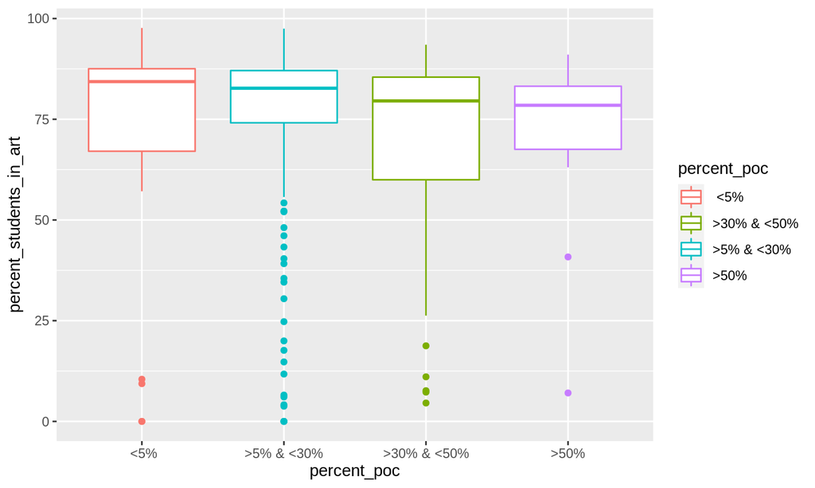

## Students That Take The SAT

Similar to the previous graph, there is a slight decreases with higher percentile poc groups, and also high variance in the data.

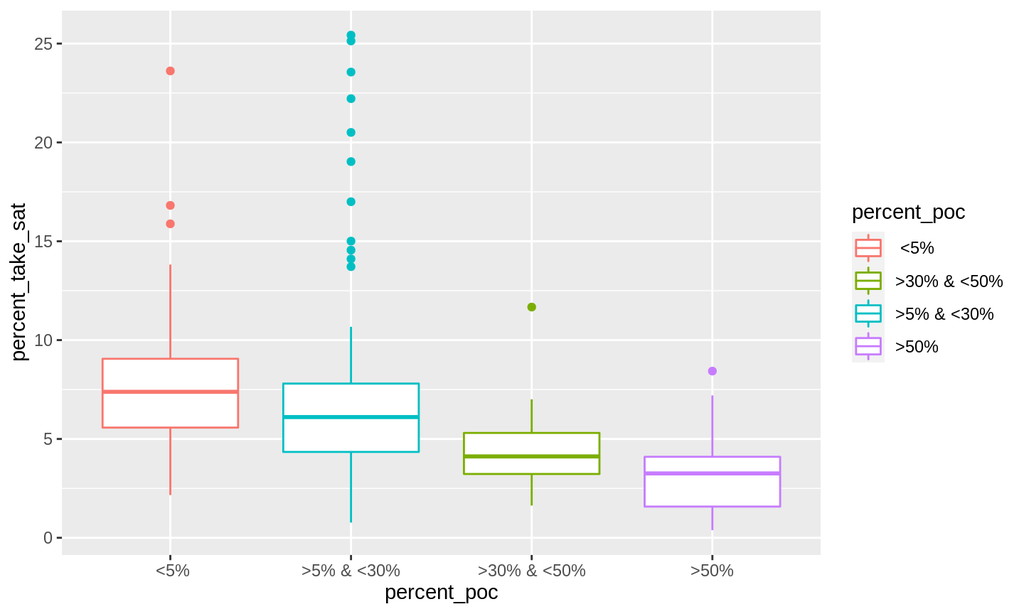

## Further Breakdown of SAT Participation

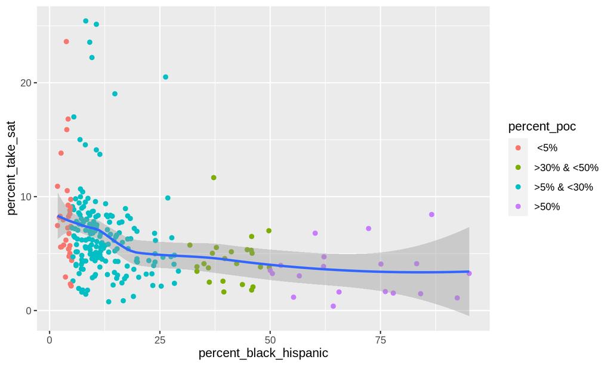

## Student Discipline

This represents any noted discipline; severity of disciplinary action is not a factor. This graph shows the most prominent trend.

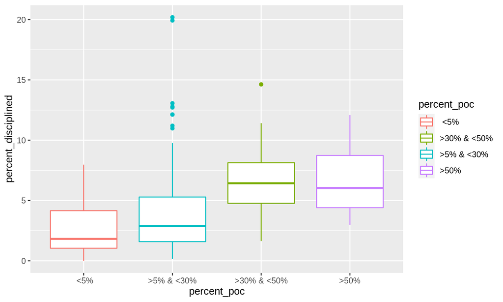

## Further Breakdown of Disciplinary Action

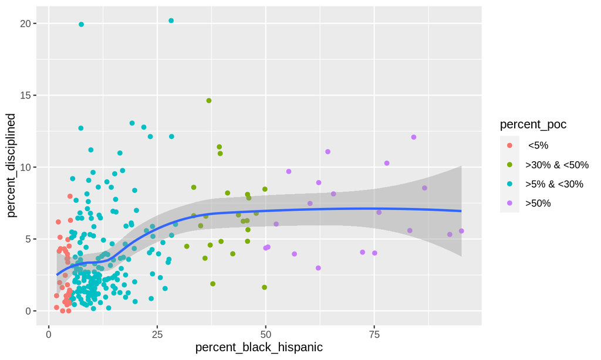

## Conclusion

There are aspects of the data that show trends. Though average teacher salary remains relatively consistent amongst school districts, other performance metrics of the schools, like sat participation and disciplinary action do tend to decrease and increase respectively with larger poc student bodies. Moving forwards I would love to analyze private school data, and delve more into specific disciplinary action that is handed out. For example, are some schools more likely to call the police on a student?

## References

School and District Profiles for The State of Massachusetts (https://profiles.doe.mass.edu/)